# Final project report

Siting Lin, Nitin Jenson, Brittnie Yi

### Research Question:

How do external, geographic factors, and pre-existing medical conditions affect the number of cases and death rates from the Coronavirus infection?

### Primary data:

This dataset is taken from https://www.worldometers.info/coronavirus/ The .CSV file for this dataset is called worldomemtersData.csv in the Github Repo.

### Secondary data:

This dataset is taken from https://www.ncbi.nlm.nih.gov/pmc/articles/PMC3551445/ The .CSV file for this dataset is called ICUnumbers.csv in the Github Repo.

This dataset is taken from https://www.kaggle.com/folaraz/world-countries-and-continents-details The .CSV file for this dataset is called countries and continents.csv in the Github Repo.

```r
# Load all packages needed
library(tidyverse)
library(ggplot2)
library(DataComputing)
library(rworldmap)
library(mosaic)
library(readr)
```

```r
# This step loads the primary and secondary datasets. Since the primary data will be updated everday, we chose to use data from the day that we finished the preliminary EDA.

file_name <- file.choose()
Worldmeters_data <-
  data.table::fread(file_name)
Worldmeters_data
```

| Country | Total Cases | New cases | Total Deaths | New death | Total Recovered | Active | Serious | Tot?Cases/1M pop | Deaths/1M pop | Total Tests | Tests/ |
| --- | --- | --- | --- | --- | --- | --- | --- | --- | --- | --- | --- |
| World | 1,272,900 | 71,417 | 69,426 | 4,736 | 262,331 | 941,143 | 45,589 | 163 | 8.90 |  |  |
| USA | 336,673 | 25,316 | 9,616 | 1,165 | 17,977 | 309,080 | 8,702 | 1,017 | 29.00 | 1,772,369 | 5,355 |
| Spain | 131,646 | 5,478 | 12,641 | 694 | 38,080 | 80,925 | 6,861 | 2,816 | 270.00 | 355,000 | 7,593 |
| France | 92,839 | 2,886 | 8,078 | 518 | 16,183 | 68,578 | 6,838 | 1,422 | 124.00 | 224,254 | 3,436 |
| Iran | 58,226 | 2,483 | 3,603 | 151 | 19,736 | 34,887 | 4,103 | 693 | 43.00 | 186,000 | 2,214 |
| Italy | 128,948 | 4,316 | 15,887 | 525 | 21,815 | 91,246 | 3,977 | 2,133 | 263.00 | 691,461 | 11,436 |
| Germany | 100,123 | 4,031 | 1,584 | 140 | 28,700 | 69,839 | 3,936 | 1,195 | 19.00 | 918,460 | 10,962 |
| UK | 47,806 | 5,903 | 4,934 | 621 | 135 | 42,737 | 1,559 | 704 | 73.00 | 195,524 | 2,880 |
| Netherlands | 17,851 | 1,224 | 1,766 | 115 | 250 | 15,835 | 1,385 | 1,042 | 103.00 | 75,415 | 4,401 |
| Turkey | 27,069 | 3,135 | 574 | 73 | 1,042 | 25,453 | 1,381 | 321 | 7.00 | 181,445 | 2,151 |

[output cut: 202 more lines]

```r
file_name2 <- file.choose()
ICUnumbers <-
  data.table::fread(file_name2)
ICUnumbers
```

| Country | ICU beds per 100,000 people | Per Capita Healthcare Cost** | Life Expectancy at Birth |
| --- | --- | --- | --- |
| United States | 25.85 | $7,164 | 79 |
| Canada | 13.50 | $3,867 | 81 |
| Denmark | 7.80 | $3,814 | 79 |
| Australia | 8.45 | $3,365 | 82 |
| South Africa | 8.90 | $843 | 54 |
| Sweden | 7.25 | $3,622 | 81 |
| Spain | 13.05 | $2,941 | 82 |
| Japan | 7.90 | $2,817 | 83 |
| UK | 7.20 | $3,222 | 80 |
| New Zealand | 5.15 | $2,655 | 81 |

[output cut: 4 more lines]

```r
file_name3 <- file.choose()
Continents <-
  data.table::fread(file_name3)
Continents
```

| name | official_name_en | official_name_fr | ISO3166-1-Alpha-2 | ISO3166-1-Alpha-3 | M49 | ITU | MARC | WMO | DS | Dial | FIFA | FIPS | GAUL | IOC | ISO4217-currency_alphabetic_code | ISO4217-currency_country_name | ISO4217-currency_minor_unit | ISO4217-currency_name | ISO4217-currency_numeric_code | is_independent | Capital | Continent | TLD | Languages | Geoname ID | EDGAR |
| --- | --- | --- | --- | --- | --- | --- | --- | --- | --- | --- | --- | --- | --- | --- | --- | --- | --- | --- | --- | --- | --- | --- | --- | --- | --- | --- |
|  | Channel Islands | ??les Anglo-Normandes |  |  | 830 |  |  |  |  |  |  |  |  |  |  |  | NA |  | NA |  |  |  |  |  | NA |  |
|  | Sark | Sercq |  |  | 680 |  |  |  |  |  |  |  |  |  |  |  | NA |  | NA |  |  |  |  |  | NA |  |
| Afghanistan | Afghanistan | Afghanistan | AF | AFG | 4 | AFG | af | AF | AFG | 93 | AFG | AF | 1 | AFG | AFN | AFGHANISTAN | 2 | Afghani | 971 | Yes | Kabul | AS | .af | fa-AF,ps,uz-AF,tk | 1149361 | B2 |
| Albania | Albania | Albanie | AL | ALB | 8 | ALB | aa | AB | AL | 355 | ALB | AL | 3 | ALB | ALL | ALBANIA | 2 | Lek | 8 | Yes | Tirana | EU | .al | sq,el | 783754 | B3 |
| Algeria | Algeria | Alg??rie | DZ | DZA | 12 | ALG | ae | AL | DZ | 213 | ALG | AG | 4 | ALG | DZD | ALGERIA | 2 | Algerian Dinar | 12 | Yes | Algiers | AF | .dz | ar-DZ | 2589581 | B4 |
| American Samoa | American Samoa | Samoa am??ricaines | AS | ASM | 16 | SMA | as |  | USA | 1-684 | ASA | AQ | 5 | ASA | USD | AMERICAN SAMOA | 2 | US Dollar | 840 | Territory of US | Pago Pago | OC | .as | en-AS,sm,to | 5880801 | B5 |
| Andorra | Andorra | Andorre | AD | AND | 20 | AND | an |  | AND | 376 | AND | AN | 7 | AND | EUR | ANDORRA | 2 | Euro | 978 | Yes | Andorra la Vella | EU | .ad | ca | 3041565 | B6 |
| Angola | Angola | Angola | AO | AGO | 24 | AGL | ao | AN | AO | 244 | ANG | AO | 8 | ANG | AOA | ANGOLA | 2 | Kwanza | 973 | Yes | Luanda | AF | .ao | pt-AO | 3351879 | B7 |
| Anguilla | Anguilla | Anguilla | AI | AIA | 660 | AIA | am |  |  | 1-264 | AIA | AV | 9 | AIA | XCD | ANGUILLA | 2 | East Caribbean Dollar | 951 | Territory of GB | The Valley | NA | .ai | en-AI | 3573511 | 1A |
| Antarctica |  |  | AQ | ATA | 10 |  | ay | AA |  | 672 | ROS | AY | 10 |  |  |  | NA |  | NA | International |  | AN | .aq |  | 6697173 |  |

[output cut: 241 more lines]

```r
# Inspection of imported data before analysis
# Using the function str() helps us see the structure of each dataset, such as its variables and variable types.

str(Worldmeters_data)
```

```
Classes ‘data.table’ and 'data.frame':  212 obs. of  12 variables:
 $ Country         : chr  "World" "USA" "Spain" "France" ...
 $ Total Cases     : chr  "1,272,900" "336,673" "131,646" "92,839" ...
 $ New cases       : chr  "71,417" "25,316" "5,478" "2,886" ...
 $ Total Deaths    : chr  "69,426" "9,616" "12,641" "8,078" ...
 $ New death       : chr  "4,736" "1,165" "694" "518" ...
 $ Total Recovered : chr  "262,331" "17,977" "38,080" "16,183" ...
 $ Active          : chr  "941,143" "309,080" "80,925" "68,578" ...
 $ Serious         : chr  "45,589" "8,702" "6,861" "6,838" ...
 $ Tot?Cases/1M pop: chr  "163" "1,017" "2,816" "1,422" ...
 $ Deaths/1M pop   : num  8.9 29 270 124 43 263 19 73 103 7 ...
 $ Total Tests     : chr  "" "1,772,369" "355,000" "224,254" ...
 $ Tests/          : chr  "" "5,355" "7,593" "3,436" ...
 - attr(*, ".internal.selfref")=<externalptr>
```

```r
str(ICUnumbers)
```

```
Classes ‘data.table’ and 'data.frame':  14 obs. of  4 variables:
 $ Country                     : chr  "United States" "Canada" "Denmark" "Australia" ...
 $ ICU beds per 100,000 people : num  25.85 13.5 7.8 8.45 8.9 ...
 $ Per Capita Healthcare Cost**: chr  "$7,164 " "$3,867 " "$3,814 " "$3,365 " ...
 $ Life Expectancy at Birth    : int  79 81 79 82 54 81 82 83 80 81 ...
 - attr(*, ".internal.selfref")=<externalptr>
```

```r
str(Continents)
```

```
Classes ‘data.table’ and 'data.frame':  251 obs. of  27 variables:
 $ name                            : chr  "" "" "Afghanistan" "Albania" ...
 $ official_name_en                : chr  "Channel Islands" "Sark" "Afghanistan" "Albania" ...
 $ official_name_fr                : chr  "??les Anglo-Normandes" "Sercq" "Afghanistan" "Albanie" ...
 $ ISO3166-1-Alpha-2               : chr  "" "" "AF" "AL" ...
 $ ISO3166-1-Alpha-3               : chr  "" "" "AFG" "ALB" ...
 $ M49                             : int  830 680 4 8 12 16 20 24 660 10 ...
 $ ITU                             : chr  "" "" "AFG" "ALB" ...
 $ MARC                            : chr  "" "" "af" "aa" ...
 $ WMO                             : chr  "" "" "AF" "AB" ...
 $ DS                              : chr  "" "" "AFG" "AL" ...
 $ Dial                            : chr  "" "" "93" "355" ...
 $ FIFA                            : chr  "" "" "AFG" "ALB" ...
 $ FIPS                            : chr  "" "" "AF" "AL" ...
 $ GAUL                            : chr  "" "" "1" "3" ...
 $ IOC                             : chr  "" "" "AFG" "ALB" ...
 $ ISO4217-currency_alphabetic_code: chr  "" "" "AFN" "ALL" ...
 $ ISO4217-currency_country_name   : chr  "" "" "AFGHANISTAN" "ALBANIA" ...
 $ ISO4217-currency_minor_unit     : int  NA NA 2 2 2 2 2 2 2 NA ...
 $ ISO4217-currency_name           : chr  "" "" "Afghani" "Lek" ...
 $ ISO4217-currency_numeric_code   : int  NA NA 971 8 12 840 978 973 951 NA ...
 $ is_independent                  : chr  "" "" "Yes" "Yes" ...
 $ Capital                         : chr  "" "" "Kabul" "Tirana" ...
 $ Continent                       : chr  "" "" "AS" "EU" ...
 $ TLD                             : chr  "" "" ".af" ".al" ...
 $ Languages                       : chr  "" "" "fa-AF,ps,uz-AF,tk" "sq,el" ...
 $ Geoname ID                      : int  NA NA 1149361 783754 2589581 5880801 3041565 3351879 3573511 6697173 ...
 $ EDGAR                           : chr  "" "" "B2" "B3" ...
 - attr(*, ".internal.selfref")=<externalptr>
```

The World Meters dataset contains 212 observations, 12 variables, and most of these variables are of ‘chr’ type besides the variable Deaths/1Mpop. The ICU numbers dataset contains 14 observations and 4 variables of different types. The Continents dataset contains 251 observations, which are all the different countries, and 27 variables.

```r
# This step cleans the data that we are going to use for analysis

ICUnew <-
  ICUnumbers %>%
  rename( Healthcare_cost = 'Per Capita Healthcare Cost**' ) %>% # Rename the variable for easy use
  mutate( Healthcare_cost = gsub(pattern = "[$]", replacement = " ", Healthcare_cost )) %>% # Edit all regular expression
  rename( 'ICUbeds' = 'ICU beds per 100,000 people' )# For easy use, abbreviate the variable's name
ICUnew
```

| Country | ICUbeds | Healthcare_cost | Life Expectancy at Birth |
| --- | --- | --- | --- |
| United States | 25.85 | 7,164 | 79 |
| Canada | 13.50 | 3,867 | 81 |
| Denmark | 7.80 | 3,814 | 79 |
| Australia | 8.45 | 3,365 | 82 |
| South Africa | 8.90 | 843 | 54 |
| Sweden | 7.25 | 3,622 | 81 |
| Spain | 13.05 | 2,941 | 82 |
| Japan | 7.90 | 2,817 | 83 |
| UK | 7.20 | 3,222 | 80 |
| New Zealand | 5.15 | 2,655 | 81 |

[output cut: 4 more lines]

```r
# Rename the variables in the data frame for ease and clarity, and select variables for analysis
Worldnew <-
  Worldmeters_data %>%
  rename( Total_Cases = `Total Cases` ) %>%
  rename( Total_Death = `Total Deaths` ) %>%
  rename( Total_Recovered = 'Total Recovered' ) %>%
  rename( Total_Tests = `Total Tests` ) %>%
  select( Country, Total_Cases, Total_Death,Total_Recovered,Total_Tests)
Worldnew
```

| Country | Total_Cases | Total_Death | Total_Recovered | Total_Tests |
| --- | --- | --- | --- | --- |
| World | 1,272,900 | 69,426 | 262,331 |  |
| USA | 336,673 | 9,616 | 17,977 | 1,772,369 |
| Spain | 131,646 | 12,641 | 38,080 | 355,000 |
| France | 92,839 | 8,078 | 16,183 | 224,254 |
| Iran | 58,226 | 3,603 | 19,736 | 186,000 |
| Italy | 128,948 | 15,887 | 21,815 | 691,461 |
| Germany | 100,123 | 1,584 | 28,700 | 918,460 |
| UK | 47,806 | 4,934 | 135 | 195,524 |
| Netherlands | 17,851 | 1,766 | 250 | 75,415 |
| Turkey | 27,069 | 574 | 1,042 | 181,445 |

[output cut: 202 more lines]

```r
Continent_new<-
  Continents %>%
  select( name, Continent ) %>%
  rename( Country = name )
Continent_new
```

| Country | Continent |
| --- | --- |
| Afghanistan | AS |
| Albania | EU |
| Algeria | AF |
| American Samoa | OC |
| Andorra | EU |
| Angola | AF |
| Anguilla | NA |
| Antarctica | AN |

[output cut: 241 more lines]

```r
NA
```

```r
# Convert all characters to integers or numbers that can be used in analysis, and join ICU dataset and World Meters dataset

Combine_data <-
  ICUnew %>%
  inner_join( Worldnew, by = "Country" ) %>%
  filter( !Country == "Zambia" ) %>% # Zambia's data is not available in this set, so we deleted it
  mutate( Total_Cases = parse_number(Total_Cases) ) %>%
  mutate( Total_Death = parse_number(Total_Death) ) %>%
  mutate( Total_Recovered = parse_number(Total_Recovered) ) %>%
  mutate( Total_Tests = parse_number(Total_Tests) ) %>%
  mutate( Healthcare_cost = parse_number(Healthcare_cost) )

Combine_data %>%
  mutate(ranks = rank(ICUbeds)) # rank to see which country has the most and least amount of beds, with 1 as the least
```

| Country | ICUbeds | Healthcare_cost | Life Expectancy at Birth | Total_Cases | Total_Death | Total_Recovered | Total_Tests | ranks |
| --- | --- | --- | --- | --- | --- | --- | --- | --- |
| Canada | 13.50 | 3867 | 81 | 15512 | 280 | 2942 | 330901 | 11 |
| Denmark | 7.80 | 3814 | 79 | 4369 | 179 | 1327 | 49249 | 6 |
| Australia | 8.45 | 3365 | 82 | 5750 | 37 | 2315 | 297154 | 8 |
| South Africa | 8.90 | 843 | 54 | 1655 | 11 | 95 | 56873 | 9 |
| Sweden | 7.25 | 3622 | 81 | 6830 | 401 | 205 | 36900 | 5 |
| Spain | 13.05 | 2941 | 82 | 131646 | 12641 | 38080 | 355000 | 10 |
| Japan | 7.90 | 2817 | 83 | 3654 | 85 | 575 | 44639 | 7 |
| UK | 7.20 | 3222 | 80 | 47806 | 4934 | 135 | 195524 | 4 |
| New Zealand | 5.15 | 2655 | 81 | 1039 | 1 | 156 | 36209 | 3 |
| China | 3.70 | 265 | 74 | 81708 | 3331 | 77078 | NA | 2 |

[output cut: 1 more lines]

```r
NA
```

# The relationship between external factors and pre_existing medical conditions

We are going to explore the relationship between external factors, such as healthcare cost, pre-existing medical conditions, using ICU numbers of 100000 people, confirmed cases, and death rate.

### Step 1: The relationship between ICU numbers, death rate, and pre_existing medical conditions

The reason that we are using these data sets is because more developed countries with larger populations are able to provide more accurate data about ICU beds, health care costs, and data about confirmed coronavirus cases. There are a few possibilities about how humans can handle COVID 19, such as having a strong immune system and recovering from the virus in isolation, or be tranfered to the ICU that can provide better medical services and care. Therefore, we hypothesize that the numbers of ICU beds avaliable and variables such as death rate in different countries may have a relationship,and we are going to explore that using the data.

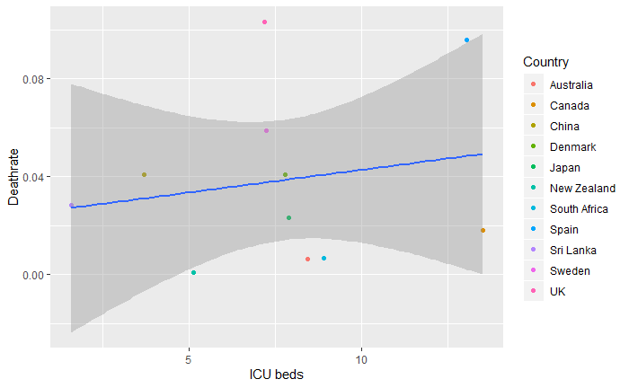

```r
# Add the new variable called death rate

ICU_Death_Rela <-
  Combine_data %>%
  select( ICUbeds, Total_Death, Total_Cases, Country ) %>%
  mutate( Deathrate = Total_Death / Total_Cases )

# Create a visualization of the relationship between death rate and ICU bed numbers in specific countries

ggplot( data = ICU_Death_Rela, aes(x = ICUbeds, y = Deathrate) ) +
  geom_point( aes(color = Country) ) +
  geom_smooth( method = lm ) +
  xlab("ICU beds")
```

There is a small number of data points due to the ICU numbers data set, which could be the reason why there is no obvious relationship between death rate and ICU numbers average. We feel that the ICU numbers data set contains accurate records, so in this analysis, we are trading a large number of data points for accuracy of the actual data. The relationship shown in the graph is positive, indicating that our hypothesis was false and that there is little relationship between ICU beds and the death rate. However, if we try to exclude some outliers, that is, to constrain the range of ICU beds from just 6 to 10, we might be able to see some form of a relationship.

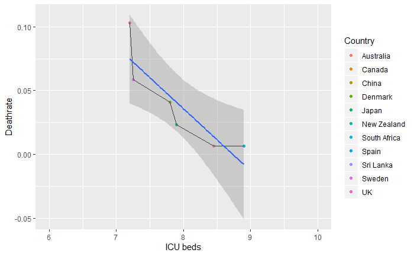

```r
ggplot( data = ICU_Death_Rela, aes(x = ICUbeds, y = Deathrate) ) +
  geom_point( aes(color = Country) ) +
  geom_line() +
  geom_smooth( method = lm ) +
  xlim( 6, 10) +
  xlab("ICU beds")
```

When we tighten the range of ICU bed numbers, there is a more obvious decresing relationship between death rate and ICU beds. However, this does not tell the whole story. Since we excluded multiple countries in this graph, coming to the conclusion of ICU bed number being related to deathrate has little accuracy and is not reliable. This showed us that there are lots of factors that were not considered that would be affecting our results, such as when these countries took action in quarantine orders. Since the data we used is already outdated, it also proves how important updating data and maintaining a database is when doing analysis in real life situations.

When looking at the previous visualization with less of a relationship, some of the outlier countries had a much different process in handling the virus than countries that did follow the trend that we ‘forced’ in the next visualization. Countries such as Spain felt the impact of the virus before the United States, and that could be why they have such a high death rate, even with more ICU bed numbers. Other factors that we may not have considered is the proximity of people living in relation to others. If people in a certain country or city lived in close quarters, the chances of them getting infectioned may be much higher than say those who live in more remote areas. All of these factors will contribute and affect the analysis, and it showed us why experts were uncertain in their predictions. Even though our hypothesis was oversimplified given the situation that we are trying to analyze, we think it opened up many interesting follow up questions and investigations. For example, we can continue to explore the close proximity versus infection rate idea by comparing population per square mile and cases of that area.

### Step 2: The relationship between average healthcare cost and total comfirmed cases.

Since news reports and analysis confirmed that the testing, medical care, and treatment of CoronaVirus are expensive, we hypothesize that the countries that have higher healthcare costs may be able to afford more tests for their population. We assume there is a relationship between total tests and healthcare cost in each of the countries.

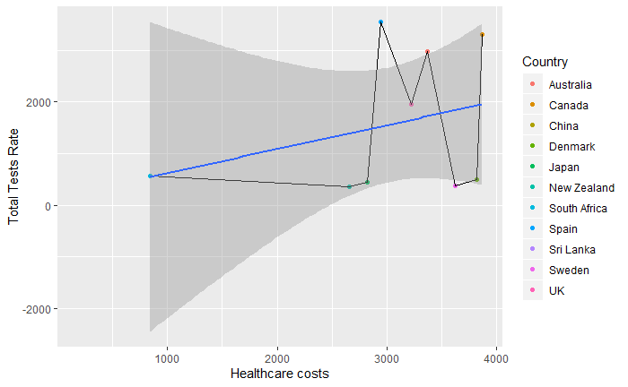

```r
Health_Test_Rela <-
  Combine_data %>%
  select( Country, Healthcare_cost, Total_Tests ) %>%
  mutate( Total_Tests_rate = Total_Tests / 100 ) # for better visualization in the graph, we changed the variable of total tests to the tests rate of 100 people

ggplot( data = Health_Test_Rela, aes(x = Healthcare_cost, y = Total_Tests_rate) ) +
  geom_point( aes(color = Country) ) +
  geom_line() +
  geom_smooth( method = lm ) +
  xlab("Healthcare costs") +
  ylab("Total Tests Rate")
```

According to the graph shown above, there is a slightly positive relationship between total tests rate and healthcare cost. However, there is still very high uncertainty with the visualization. In addition, when we collected the data that are used for the analysis, testing for the virus was still not widely available in certain countries, which could be contributing to the amount of variation between the data points.

# The relationship between geographic factor and numbers of cases confirmed

We are going to make a graph for futher exploration of the relationship between geographic factors and total cases comfirmed.

```r
Con_Case_Rela <-
  Continent_new %>%
  inner_join( Worldnew ) %>%
  mutate( Total_Cases = parse_number( Total_Cases ) ) %>%
  mutate( Total_Death = parse_number( Total_Death ) ) %>%
  filter( !Total_Death == "NA" ) %>%
  group_by( Continent ) %>%
  summarise( Total_Cases_conti = sum(Total_Cases),
             Total_Death_conti = sum(Total_Death) ) %>%
  mutate( Deathrate_conti = Total_Death_conti / Total_Cases_conti )
Con_Case_Rela
```

| Continent | Total_Cases_conti | Total_Death_conti | Deathrate_conti |
| --- | --- | --- | --- |
| AF | 8402 | 419 | 0.04986908 |
| AS | 211516 | 8435 | 0.03987878 |
| EU | 639596 | 49113 | 0.07678753 |
| OC | 6789 | 38 | 0.00559729 |
| SA | 25551 | 895 | 0.03502798 |
| NA | 22640 | 552 | 0.02438163 |

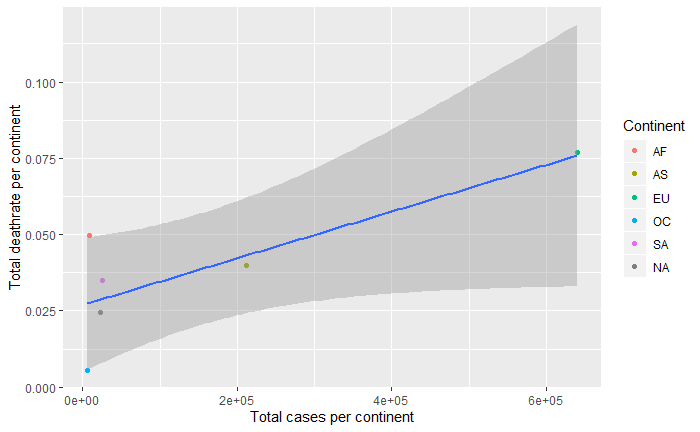

```r
ggplot( data = Con_Case_Rela, aes(x = Total_Cases_conti, y = Deathrate_conti) ) +
  geom_point( aes(color = Continent) ) +
  xlab("Total cases per continent") +
  ylab("Total deathrate per continent") +
  geom_smooth( method = lm )
```

According to the graph above, we can see that total cases in each continent are similar besides Asia and Europe. There is a positive relationship between number of cases and number of death rate, which was expected. It is interesting to see how continents like Africa has high deathrate and low cases, which can indecate the virus having a higher mortality rate there.